# Assignment 3

Sivert Jakobsen

28 10 2020

## Introduksjon

Haun et al. (2019) samlet inn data fra 30 menn i høyskolealer for å se på effekten av 6 uker med styrketrening med høy motstand hvor han så på hvordan flere fysiologiske parametere forandret seg. Etter pre-test ble de 20 med lavest og høyest respons delt inn i to grupper, HIGH- og LOW-responders.

I denne oppgaven skal jeg se på korrelasjonen mellom ulike variabbler i datasettet til Haun et al (2019). I del 1 vil jeg sammenligne metodene t-test og regresjonsanalyse. Del 2 vil handle om å se på sammenhengen mellom muskelmasse og styrke ved hjelp av regresjon og korrelasjonsanalyse.

## Del 1 - t-test og regresjons analyse

Variablene som blir testet er AVG_CSA_T1. Denne variablene er tversnittarealet av vastus lateralis ved pre-test. I denne delen av oppgaven skal jeg sammenligne resultatene fra en t-test og regesjonsanalyse.

I disse testene vil vi se om det er en forskjell av tversnittarelaet mellom de to gruppene. For å gjennomføre t-testen setter vi to hypoteser. H0-hypotese: det er ingen signifikant forskjell mellom de to gruppene. H1-hypotese: det er en signifikant forskjell mellom de to gruppene. Resultatene av t-testen vises i tabellen under (tabell 1).

Tabell 1: T-test

| Gj.snitt LOW | Gj.snitt HIGH | T-verdi | P-verdi | DF | CI LOW | CI High |
| --- | --- | --- | --- | --- | --- | --- |
| 4538.571 | 3588.428 | 2.749118 | 0.0131971 | 18 | 224.0279 | 1676.258 |

I tabell 1 ser vi gjennomsnittet av tversnittarealet hos de to gruppene LOW og HIGH. T-testen ga en p-verdi på p = 0.013. Dette vil si at det er en signifikant forskjell i tverrnittarealet hos de to gruppene. Regresjonsmodellen vises under (Tabell 2).

Tabell 2: Regresjons modell

|  | Estimate | SE | t-statistic | p-value |
| --- | --- | --- | --- | --- |
| (Intercept) | 4538.6 | 244.4 | 18.57 | 0.000 |
| CLUSTERHIGH | -950.1 | 345.6 | -2.75 | 0.013 |

Regresjonsmodellen ga en p-verdig på p = 0,013. Ut ifra dette kan vi tolke at t-testen og regresjons analysen viser at det er en signifikant forskjell mellom guppene.

## Del 2 - forholdet mellom muskelmasse og styrke

I denne delen vil vi se om det er en sammenheng mellom muskelmasse og styrke i datasettet til Haun et.al. (2019). Vi henter ut variablene Squat_3RM_kg og AVG_CSA_T1. Disse sier noe om hvor mange kg forsøkspersonene klarer i 3RM og tversnittarealet av vastus lateralis pre-test.

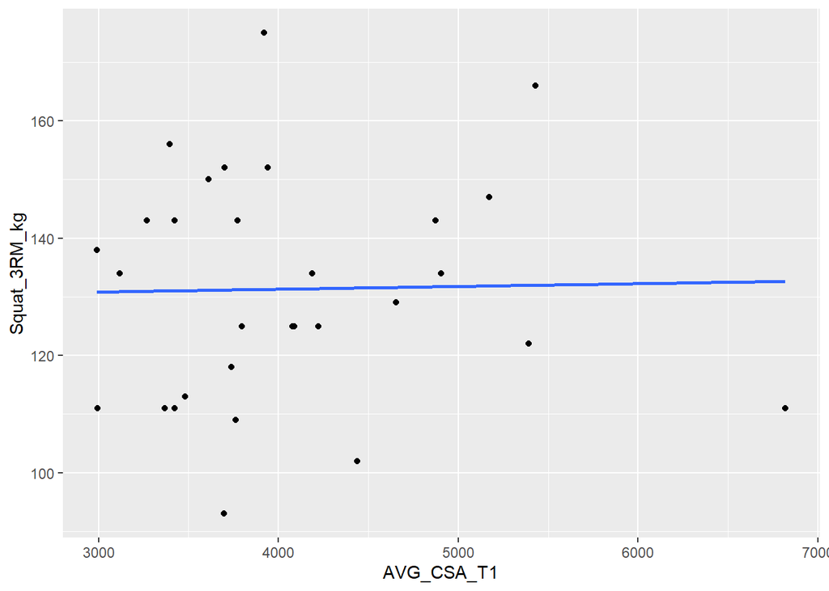

Tabell 3: Correlasjon

| estimate | statistic | p.value | parameter | conf.low | conf.high | method |
| --- | --- | --- | --- | --- | --- | --- |
| 0.0206866 | 0.1094865 | 0.9135975 | 28 | -0.3421325 | 0.3781376 | Pearson’s product-moment correlation |

Når man gjøre en korrelasjonstest vil man ha en verdi på 1 eller -1 for at det skal være en korrelasjon. Korrelasjonstesten Pearson viser til en correlasjon på 0.021 som vi si at det er svært liten korrelasjon.

Tabell 4: Regresjon

|  | Estimate | SE | t-statistic | p-value |
| --- | --- | --- | --- | --- |
| (Intercept) | 129.4153 | 17.8891 | 7.2343 | 0.0000 |
| AVG_CSA_T1 | 0.0005 | 0.0043 | 0.1095 | 0.9136 |

Regresjonsmodellen viser diverse forskjellige verdier, men jeg sliter litt med hvordan jeg skal tolke dem.